# Hominin ECV Analysis

Author

Jyhreh Johnson

Published

November 18, 2026

# Week 13 - Statistical Modeling and Quarto

## Part 1: Setting Up Quarto

### 1.3 First Chunk: Load the Data

```python
import pandas as pd
import numpy as np
import statsmodels.formula.api as smf
import patsy
from plotnine import *

ecv = pd.read_csv("~/Documents/UT/comp_paleo/part3_AL/week11/ecv_by_specimen.csv")

# Put the grades in evolutionary order (otherwise they will be sorted alphabetically)
grade_order = ["archaic", "mega", "trans", "pre.mod"]
ecv["grade"] = pd.Categorical(ecv["grade"], categories=grade_order, ordered=True)

print(ecv.shape)
print("Missing grades:", ecv["grade"].isna().sum())
ecv.head()
```

```
(94, 8)
Missing grades: 0
```

|  | ID | taxon | grade | ecv_median_cm3 | n_estimates | age_mid_Ma | age_lo_Ma | age_hi_Ma |
| --- | --- | --- | --- | --- | --- | --- | --- | --- |
| 0 | AL 162-28 | Au. afarensis | archaic | 383.8 | 2 | 3.220 | 3.20 | 3.24 |
| 1 | AL 333-105 | Au. afarensis | archaic | 371.5 | 2 | 3.220 | 3.20 | 3.24 |
| 2 | AL 333-45 | Au. afarensis | archaic | 492.5 | 2 | 3.220 | 3.20 | 3.24 |
| 3 | AL 822-1 | Au. afarensis | archaic | 385.0 | 1 | 3.100 | 3.10 | 3.10 |
| 4 | AL 288-1 | Au. afarensis | archaic | 387.5 | 1 | 3.075 | 2.95 | 3.20 |

## Part 2: Patsy Deisgn Matrics

### 2.1 Build a Simple Design Matrix

```python
import patsy

y, X = patsy.dmatrices("ecv_median_cm3 ~ age_mid_Ma", data=ecv, return_type="dataframe")
print("Response (y):")
print(y.head())
print("\nDesign matrix (X):")
print(X.head())
print("\nX columns:", X.columns.tolist())
```

```
Response (y):
   ecv_median_cm3
0           383.8
1           371.5
2           492.5
3           385.0
4           387.5

Design matrix (X):
   Intercept  age_mid_Ma
0        1.0       3.220
1        1.0       3.220
2        1.0       3.220
3        1.0       3.100
4        1.0       3.075

X columns: ['Intercept', 'age_mid_Ma']
```

**Question 2.1: What are the two columns in X? What is the value of the intercept column for every row, and why?**

- X is a matrix rather than a series. The two columns are vectors of 1s and X values: Intercept and age_mid_Ma. Intercept is fitting a linear model to estimate the slope and vertical offset.

### 2.2 Build a Multiple Design Matrix

```python
y2, X2 = patsy.dmatrices(
    "ecv_median_cm3 ~ age_mid_Ma + C(grade)", data=ecv, return_type="dataframe"
)
print("X2 shape:", X2.shape)
print("X2 columns:", X2.columns.tolist())
print(X2.head(8))
```

```
X2 shape: (94, 5)
X2 columns: ['Intercept', 'C(grade)[T.mega]', 'C(grade)[T.trans]', 'C(grade)[T.pre.mod]', 'age_mid_Ma']
   Intercept  C(grade)[T.mega]  C(grade)[T.trans]  C(grade)[T.pre.mod]  \
0        1.0               0.0                0.0                  0.0
1        1.0               0.0                0.0                  0.0
2        1.0               0.0                0.0                  0.0
3        1.0               0.0                0.0                  0.0
4        1.0               0.0                0.0                  0.0
5        1.0               0.0                0.0                  0.0
6        1.0               0.0                0.0                  0.0
7        1.0               0.0                0.0                  0.0

   age_mid_Ma
0       3.220
1       3.220
2       3.220
3       3.100
4       3.075
5       3.075
6       2.805
7       2.715
```

**Question 2.2: How many columns does X2 have, and what does each one represent? Which grade is the reference level (the one that does NOT get its own dummy column)?**

- X2 has 5 columns. Each column represents the Intercept, dummy variables: C(grade)[T.mega], C(grade)[T.trans], and C(grade)[T.pre.mod] representing the different levels in my categorical variable, and the age_mid_Ma. Archaic is the reference level becasue we defined the caterogical order.

### 2.3 Inspect the Encoding

```python
col = "C(grade)[T.mega]"
rows = X2.index[X2[col] == 1]
print(f"Rows where {col} == 1:")
print(ecv.loc[rows, ["taxon", "grade", "ecv_median_cm3", "age_mid_Ma"]].head())
```

```
Rows where C(grade)[T.mega] == 1:
             taxon grade  ecv_median_cm3  age_mid_Ma
9   P. aethiopicus  mega           410.0       2.526
10       Au. garhi  mega           450.0       2.473
11  P. aethiopicus  mega           427.0       2.350
17       P. boisei  mega           490.0       2.200
19     P. robustus  mega           476.0       1.980
```

## Fitting a Model

```python
import statsmodels.formula.api as smf

# Fit: smf.ols takes the same formula string Patsy does
model = smf.ols("ecv_median_cm3 ~ age_mid_Ma", data=ecv).fit()

# Print the full results table
print(model.summary())
```

```
                            OLS Regression Results
==============================================================================
Dep. Variable:         ecv_median_cm3   R-squared:                       0.750
Model:                            OLS   Adj. R-squared:                  0.748
Method:                 Least Squares   F-statistic:                     276.6
Date:                Thu, 19 Nov 2026   Prob (F-statistic):           1.79e-29
Time:                        15:58:17   Log-Likelihood:                -593.86
No. Observations:                  94   AIC:                             1192.
Df Residuals:                      92   BIC:                             1197.
Df Model:                           1
Covariance Type:            nonrobust
==============================================================================
                 coef    std err          t      P>|t|      [0.025      0.975]
------------------------------------------------------------------------------
Intercept   1201.4004     30.168     39.824      0.000    1141.485    1261.316
age_mid_Ma  -294.1412     17.686    -16.631      0.000    -329.268    -259.015
==============================================================================
Omnibus:                        1.090   Durbin-Watson:                   1.631
Prob(Omnibus):                  0.580   Jarque-Bera (JB):                1.129
Skew:                           0.164   Prob(JB):                        0.569
Kurtosis:                       2.574   Cond. No.                         4.73
==============================================================================

Notes:
[1] Standard Errors assume that the covariance matrix of the errors is correctly specified.
```

## Accessing Results Programmatically

```python
# Individual attributes
print("R-squared:", model.rsquared)
print("Intercept:", model.params["Intercept"])
print("Slope on age:", model.params["age_mid_Ma"])
print("p-value on age:", model.pvalues["age_mid_Ma"])

# Predicted values and residuals
ecv["fitted"] = model.fittedvalues
ecv["resid"] = model.resid
```

```
R-squared: 0.7503997842305423
Intercept: 1201.4003560593342
Slope on age: -294.14119327362647
p-value on age: 1.7904571784591334e-29
```

## Part 3: OLS Regression

### 3.1 Simple Regression: ECV ~age

```python
model1 = smf.ols("ecv_median_cm3 ~ age_mid_Ma", data=ecv).fit()
print(model1.summary())
```

```
                            OLS Regression Results
==============================================================================
Dep. Variable:         ecv_median_cm3   R-squared:                       0.750
Model:                            OLS   Adj. R-squared:                  0.748
Method:                 Least Squares   F-statistic:                     276.6
Date:                Thu, 19 Nov 2026   Prob (F-statistic):           1.79e-29
Time:                        15:58:17   Log-Likelihood:                -593.86
No. Observations:                  94   AIC:                             1192.
Df Residuals:                      92   BIC:                             1197.
Df Model:                           1
Covariance Type:            nonrobust
==============================================================================
                 coef    std err          t      P>|t|      [0.025      0.975]
------------------------------------------------------------------------------
Intercept   1201.4004     30.168     39.824      0.000    1141.485    1261.316
age_mid_Ma  -294.1412     17.686    -16.631      0.000    -329.268    -259.015
==============================================================================
Omnibus:                        1.090   Durbin-Watson:                   1.631
Prob(Omnibus):                  0.580   Jarque-Bera (JB):                1.129
Skew:                           0.164   Prob(JB):                        0.569
Kurtosis:                       2.574   Cond. No.                         4.73
==============================================================================

Notes:
[1] Standard Errors assume that the covariance matrix of the errors is correctly specified.
```

**Question 3.1: Report the slope, its p-value, and the R-squared. Is ECV significantly associated with age in this model? What does the sign of the slope tell you biologically?**

### 3.2 Multiple Regression: ECV ~age + grade

```python
model2 = smf.ols("ecv_median_cm3 ~ age_mid_Ma + C(grade)", data=ecv).fit()
print(model2.summary())
```

```
                            OLS Regression Results
==============================================================================
Dep. Variable:         ecv_median_cm3   R-squared:                       0.809
Model:                            OLS   Adj. R-squared:                  0.800
Method:                 Least Squares   F-statistic:                     94.05
Date:                Thu, 19 Nov 2026   Prob (F-statistic):           4.03e-31
Time:                        15:58:17   Log-Likelihood:                -581.36
No. Observations:                  94   AIC:                             1173.
Df Residuals:                      89   BIC:                             1185.
Df Model:                           4
Covariance Type:            nonrobust
=======================================================================================
                          coef    std err          t      P>|t|      [0.025      0.975]
---------------------------------------------------------------------------------------
Intercept            1056.1445     80.205     13.168      0.000     896.779    1215.510
C(grade)[T.mega]      -97.4736     45.891     -2.124      0.036    -188.658      -6.289
C(grade)[T.trans]     -12.3418     58.120     -0.212      0.832    -127.826     103.142
C(grade)[T.pre.mod]   113.0874     58.442      1.935      0.056      -3.035     229.210
age_mid_Ma           -226.3810     27.979     -8.091      0.000    -281.975    -170.787
==============================================================================
Omnibus:                        3.762   Durbin-Watson:                   1.562
Prob(Omnibus):                  0.152   Jarque-Bera (JB):                3.096
Skew:                           0.415   Prob(JB):                        0.213
Kurtosis:                       3.317   Cond. No.                         18.1
==============================================================================

Notes:
[1] Standard Errors assume that the covariance matrix of the errors is correctly specified.
```

**Question 3.2: Compare R-squared between model1 and model2. Does adding grade improve fit? Interpret the C(grade)[T.pre.mod] coefficient what do its sign and size tell you about pre.mod specimens compared with archaic specimens of the same age?**

- Adding grade did improve the fit as the R-squared increased from 75% to 80%. As more parameters are introduced, the fit will improve. Adjusted R-squared also rose (0.748 → 0.800). Adding grade also reduced the age slope from −294 to −226. Meaning part of the age effect in model1 reflected which grades are present at different times. The coefficient of C(grade)[T.pre.mod] is 113.1 cm3. Because archaic is the reference grade, this is the difference in predicted ECV between a pre.mod specimen and an archaic specimen of the same age. The sign is positive and the size is about 113 cm3.

### 3.3 Residual Diagnostic Plot

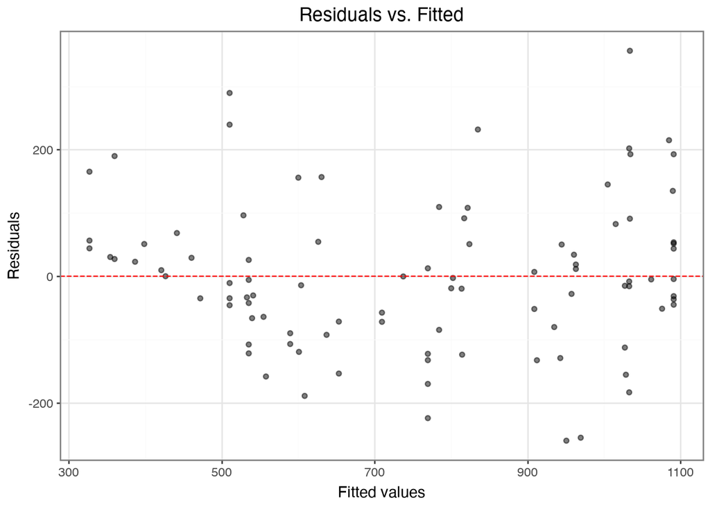

Figure 1: Residuals vs. Fitted Values for the Multiple Regression Model

```python
ecv_diag = ecv.copy()
ecv_diag["fitted"] = model2.fittedvalues
ecv_diag["resid"] = model2.resid

diag_plot = (
    ggplot(ecv_diag, aes(x="fitted", y="resid"))
    + geom_point(alpha=0.5)
    + geom_hline(yintercept=0, color="red", linetype="dashed")
    + labs(x="Fitted values", y="Residuals", title="Residuals vs. Fitted")
    + theme_bw()
)
diag_plot
```

**Question 3.3: Describe the pattern (or lack of pattern) in the residual plot. Are there any obvious outliers or trends that suggest the OLS assumptions are violated?**

### 3.4 Interaction Term

```python
model3 = smf.ols("ecv_median_cm3 ~ age_mid_Ma * C(grade)", data=ecv).fit()
print(model3.summary())
```

```
                            OLS Regression Results
==============================================================================
Dep. Variable:         ecv_median_cm3   R-squared:                       0.841
Model:                            OLS   Adj. R-squared:                  0.828
Method:                 Least Squares   F-statistic:                     65.12
Date:                Thu, 19 Nov 2026   Prob (F-statistic):           1.12e-31
Time:                        15:58:17   Log-Likelihood:                -572.59
No. Observations:                  94   AIC:                             1161.
Df Residuals:                      86   BIC:                             1182.
Df Model:                           7
Covariance Type:            nonrobust
==================================================================================================
                                     coef    std err          t      P>|t|      [0.025      0.975]
--------------------------------------------------------------------------------------------------
Intercept                        570.3536    172.456      3.307      0.001     227.522     913.185
C(grade)[T.mega]                  84.5529    253.678      0.333      0.740    -419.743     588.849
C(grade)[T.trans]               -147.4633    431.195     -0.342      0.733   -1004.650     709.723
C(grade)[T.pre.mod]              659.1307    175.579      3.754      0.000     310.092    1008.170
age_mid_Ma                       -43.4821     64.070     -0.679      0.499    -170.850      83.886
age_mid_Ma:C(grade)[T.mega]      -27.3748    113.999     -0.240      0.811    -253.997     199.248
age_mid_Ma:C(grade)[T.trans]     172.5938    234.073      0.737      0.463    -292.727     637.915
age_mid_Ma:C(grade)[T.pre.mod]  -245.0098     70.742     -3.463      0.001    -385.640    -104.380
==============================================================================
Omnibus:                        6.998   Durbin-Watson:                   1.638
Prob(Omnibus):                  0.030   Jarque-Bera (JB):                6.857
Skew:                           0.492   Prob(JB):                       0.0324
Kurtosis:                       3.885   Cond. No.                         93.3
==============================================================================

Notes:
[1] Standard Errors assume that the covariance matrix of the errors is correctly specified.
```

**Question 3.4: What does the interaction term age_mid_Ma:C(grade)[T.pre.mod] test? Is it statistically significant? Does adding the interaction improve R-squared?**

- The interaction term tests whether the slope of ECV on age is different for pre-mod than for archaic hominins. ECV changed through time at a different rate in pre.mod specimens. The null hypothesis is that the two grades share the same slope. The interaction term is statistically significant: the coefficient is −245.0 cm3. Adding it to the archaic slope (−43.5 cm3) gives a pre.mod slope of −288.5 cm3. The mega and trans interaction terms are not significant (p = 0.81 and p = 0.46). Adding the interaction terms increased R-squared from 0.809 (model2) to 0.841 (model3). Adjusted R-squared also increased (0.800 -> 0.828).

## Part 4: Figures and Inline Results in Quarto

### 4.1 A Polished Figure with a Cross-Reference

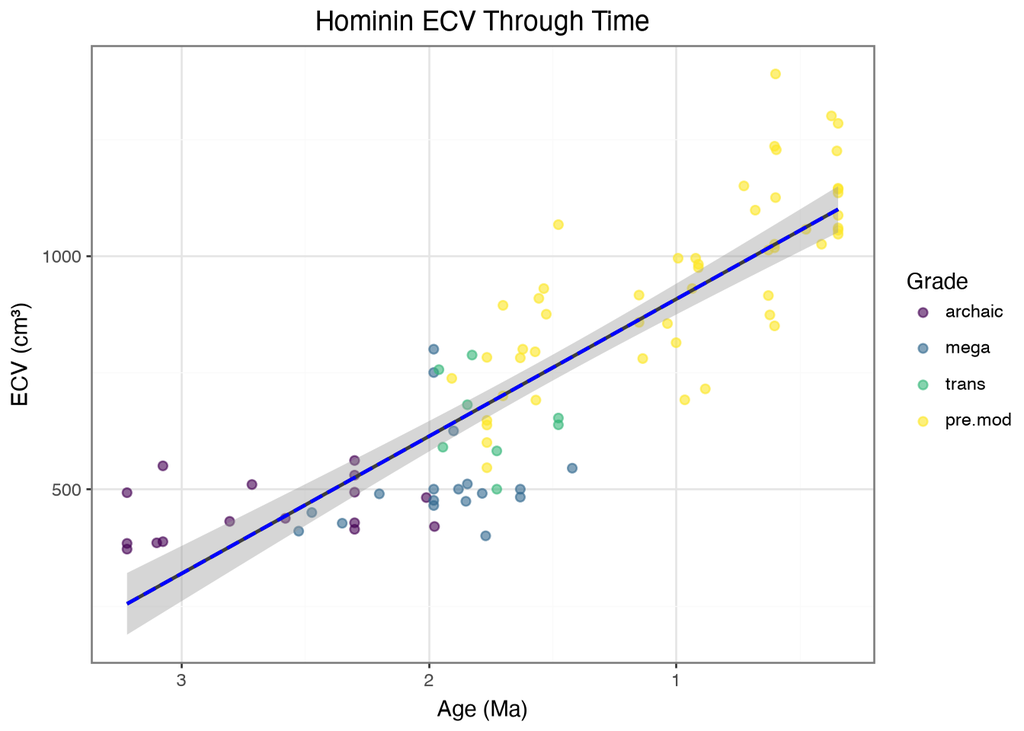

Figure 2: Observed ECV and OLS fitted line (ECV ~ age). Points colored by grade.

```python
pred = pd.DataFrame(
    {"age_mid_Ma": np.linspace(ecv["age_mid_Ma"].min(), ecv["age_mid_Ma"].max(), 200)}
)
pred["ecv_pred"] = model1.predict(pred)

polished_fig = (
    ggplot(ecv, aes(x="age_mid_Ma", y="ecv_median_cm3", color="grade"))
    + geom_point(alpha=0.6, size=2)
    + geom_line(
        aes(x="age_mid_Ma", y="ecv_pred"),
        data=pred,
        color="black",
        size=1,
        inherit_aes=False,
    )
    + geom_smooth(method="lm", color="blue", linetype="dashed")
    + scale_x_reverse()
    + labs(x="Age (Ma)", y="ECV (cm³)", color="Grade", title="Hominin ECV Through Time")
    + theme_bw()
)
polished_fig
```

As shown in Figure 2, ECV increases toward the present, though considerable variation is present across grades.

**Question 4.1: Render the document and confirm that Figure 2 resolves to “Figure 1” (or the appropriate number) in the HTML output. If the reference does not resolve, what does Quarto show instead, and what does that tell you about the label?**

- The reference resolves in the rendered html. If the reference did not resolve, Quarto would show the raw label in bold with a warning. The html would have down arrow and “Code”. Meaning Quarto could not find a figure with that label or the chunk did not produce a figure.

### 4.2 Inline Python Results

The simple regression explains 0.75 of the variance in ECV. For every additional million years into the past, ECV decreases by 294.1 cc on average (p = 1.8e-29).

### 4.3 A Model Comparison Table

```python
comparison = pd.DataFrame(
    {
        "Model": ["ECV ~ age", "ECV ~ age + C(grade)", "ECV ~ age * C(grade)"],
        "R-squared": [round(m.rsquared, 3) for m in [model1, model2, model3]],
        "Adj. R-squared": [round(m.rsquared_adj, 3) for m in [model1, model2, model3]],
        "AIC": [round(m.aic, 1) for m in [model1, model2, model3]],
        "N": [int(m.nobs) for m in [model1, model2, model3]],
    }
)
comparison
```

Table 1: Comparison of three OLS models for ECV

|  | Model | R-squared | Adj. R-squared | AIC | N |
| --- | --- | --- | --- | --- | --- |
| 0 | ECV ~ age | 0.750 | 0.748 | 1191.7 | 94 |
| 1 | ECV ~ age + C(grade) | 0.809 | 0.800 | 1172.7 | 94 |
| 2 | ECV ~ age * C(grade) | 0.841 | 0.828 | 1161.2 | 94 |

**Question 4.2: Based on this table, which model fits best according to adjusted R-squared? Which fits best according to AIC (lower is better)? Do the two criteria agree?**